# 6885Homework1_Subedi_Kamal

## Computer Vision

### Kamal Subedi (G35111003)

### Homework 1

Using any software that you like (MATLAB, ImageJ, OpenCV, Python, C, etc.) and any five images of different complexity, do the following for each image:

1. Read in and display the image
2. Display the image of the magnitude of its Fourier transform
3. Remove alternate rows and columns of the original image, and repeat Step 2
4. Replicate each row and column of the original image, and repeat Step 2.
5. What do you conclude about the effects of the changes to the images? Comment on whether and how the changes depended on the content of the original image.

# Images used are: image 1: https://unsplash.com/photos/a-mountain-with-a-lake-in-front-of-it-87Bm-w4J0bc image 2: https://unsplash.com/photos/a-plane-flying-over-a-mountain-range-at-sunset-Z30EBohFtqU image 3: https://www.pexels.com/photo/18265422/ image 4: https://www.pexels.com/photo/man-people-art-street-18277249/ image 5: https://unsplash.com/photos/a-view-of-a-city-at-night-from-the-top-of-a-tall-building-ynQNodjhlk4

```python
# Image 1
# Read in and display the image
```

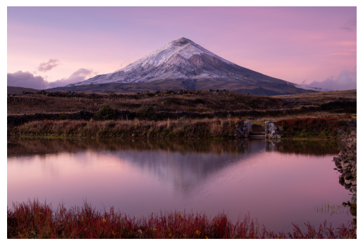

```python
import cv2
import numpy as np
import matplotlib.pyplot as plt

# Load the image
image1 = cv2.imread("image1.jpg")

# Display the loaded image using Matplotlib
plt.imshow(cv2.cvtColor(image1, cv2.COLOR_BGR2RGB))
plt.axis('off')  # Turn off axis labels
plt.show()
```

```python
# Display the image of the magnitude of its Fourier transform
```

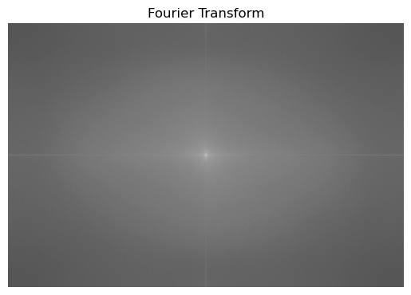

```python
# Convert the image to grayscale
gray1 = cv2.cvtColor(image1, cv2.COLOR_BGR2GRAY)

# Compute the discrete Fourier Transform of the image
fourier1 = cv2.dft(np.float32(gray1), flags=cv2.DFT_COMPLEX_OUTPUT)

# Shift the zero-frequency component to the center of the spectrum
fourier_shift = np.fft.fftshift(fourier1)

# Calculate the magnitude of the Fourier Transform
magnitude = 20 * np.log(cv2.magnitude(fourier_shift[:, :, 0], fourier_shift[:, :, 1]))

# Scale the magnitude for display
magnitude1 = cv2.normalize(magnitude, None, 0, 255, cv2.NORM_MINMAX, cv2.CV_8UC1)

# Display the magnitude of the Fourier Transform using matplotlib
plt.imshow(magnitude1, cmap='gray')
plt.title('Fourier Transform')
plt.axis('off')  # Turn off axis labels
plt.show()
```

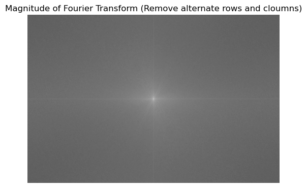

```python
# Remove alternate rows and columns from the grayscale image
gray_subsampled1 = gray1[::2, ::2]

# Compute the discrete Fourier Transform of the subsampled image
fourier1_1 = cv2.dft(np.float32(gray_subsampled1), flags=cv2.DFT_COMPLEX_OUTPUT)

# Shift the zero-frequency component to the center of the spectrum
fourier_shift = np.fft.fftshift(fourier1_1)

# Calculate the magnitude of the Fourier Transform
magnitude = 20 * np.log(cv2.magnitude(fourier_shift[:, :, 0], fourier_shift[:, :, 1]))

# Scale the magnitude for display
magnitude1_1 = cv2.normalize(magnitude, None, 0, 255, cv2.NORM_MINMAX, cv2.CV_8UC1)

# Display the magnitude of the Fourier Transform using matplotlib
plt.imshow(magnitude1_1, cmap='gray')
plt.title('Magnitude of Fourier Transform (Remove alternate rows and cloumns)')
plt.axis('off')  # Turn off axis labels
plt.show()
```

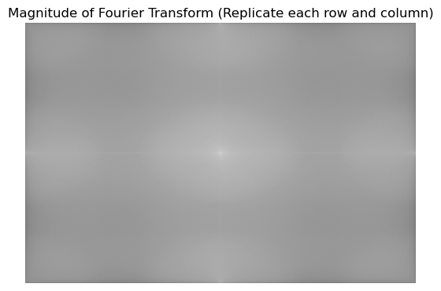

```python
# Replicate each row and column of the grayscale image
gray_expanded1 = gray1.repeat(2, axis=0).repeat(2, axis=1)

# Compute the discrete Fourier Transform of the expanded image
fourier1_2 = cv2.dft(np.float32(gray_expanded1), flags=cv2.DFT_COMPLEX_OUTPUT)

# Shift the zero-frequency component to the center of the spectrum
fourier_shift = np.fft.fftshift(fourier1_2)

# Calculate the magnitude of the Fourier Transform with a small constant added to avoid divide by zero
magnitude = 20 * np.log(cv2.magnitude(fourier_shift[:, :, 0], fourier_shift[:, :, 1]) + 1e-6)

# Scale the magnitude for display
magnitude1_2 = cv2.normalize(magnitude, None, 0, 255, cv2.NORM_MINMAX, cv2.CV_8UC1)

# Display the magnitude of the Fourier Transform using matplotlib
plt.imshow(magnitude1_2, cmap='gray')
plt.title('Magnitude of Fourier Transform (Replicate each row and column)')
plt.axis('off')  # Turn off axis labels
plt.show()
```

```python
# Image 2
# Read in and display the image
```

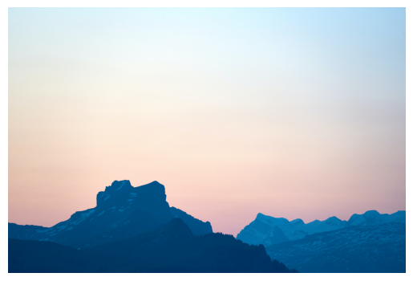

```python
# Load the image
image2 = cv2.imread("image2.jpg")

# Display the loaded image using Matplotlib
plt.imshow(cv2.cvtColor(image2, cv2.COLOR_BGR2RGB))
plt.axis('off')  # Turn off axis labels
plt.show()
```

```python
# Display the image of the magnitude of its Fourier transform
```

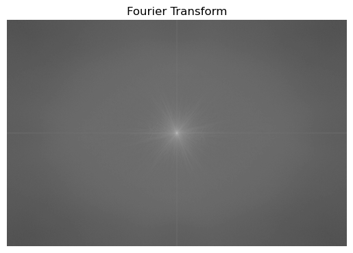

```python
# Convert the image to grayscale
gray2 = cv2.cvtColor(image2, cv2.COLOR_BGR2GRAY)

# Compute the discrete Fourier Transform of the image
fourier2 = cv2.dft(np.float32(gray2), flags=cv2.DFT_COMPLEX_OUTPUT)

# Shift the zero-frequency component to the center of the spectrum
fourier_shift = np.fft.fftshift(fourier2)

# Calculate the magnitude of the Fourier Transform
magnitude = 20 * np.log(cv2.magnitude(fourier_shift[:, :, 0], fourier_shift[:, :, 1]))

# Scale the magnitude for display
magnitude2 = cv2.normalize(magnitude, None, 0, 255, cv2.NORM_MINMAX, cv2.CV_8UC1)

# Display the magnitude of the Fourier Transform using matplotlib
plt.imshow(magnitude2, cmap='gray')
plt.title('Fourier Transform')
plt.axis('off')  # Turn off axis labels
plt.show()
```

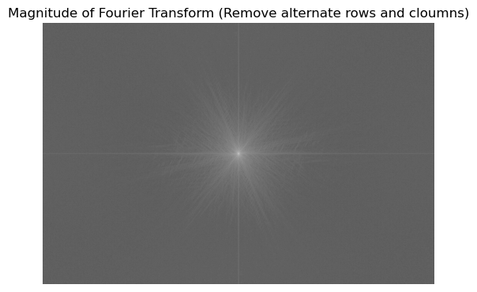

```python
# Remove alternate rows and columns from the grayscale image
gray_subsampled2 = gray2[::2, ::2]

# Compute the discrete Fourier Transform of the subsampled image
fourier2_1 = cv2.dft(np.float32(gray_subsampled2), flags=cv2.DFT_COMPLEX_OUTPUT)

# Shift the zero-frequency component to the center of the spectrum
fourier_shift = np.fft.fftshift(fourier2_1)

# Calculate the magnitude of the Fourier Transform
magnitude = 20 * np.log(cv2.magnitude(fourier_shift[:, :, 0], fourier_shift[:, :, 1]))

# Scale the magnitude for display
magnitude2_1 = cv2.normalize(magnitude, None, 0, 255, cv2.NORM_MINMAX, cv2.CV_8UC1)

# Display the magnitude of the Fourier Transform using matplotlib
plt.imshow(magnitude2_1, cmap='gray')
plt.title('Magnitude of Fourier Transform (Remove alternate rows and cloumns)')
plt.axis('off')  # Turn off axis labels
plt.show()
```

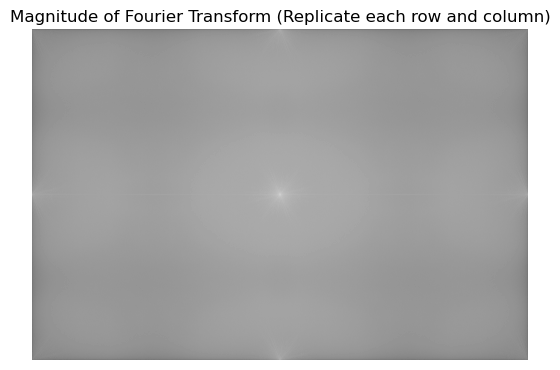

```python
# Replicate each row and column of the grayscale image
gray_expanded2 = gray2.repeat(2, axis=0).repeat(2, axis=1)

# Compute the discrete Fourier Transform of the expanded image
fourier2_2 = cv2.dft(np.float32(gray_expanded2), flags=cv2.DFT_COMPLEX_OUTPUT)

# Shift the zero-frequency component to the center of the spectrum
fourier_shift = np.fft.fftshift(fourier2_2)

# Calculate the magnitude of the Fourier Transform with a small constant added to avoid divide by zero
magnitude = 20 * np.log(cv2.magnitude(fourier_shift[:, :, 0], fourier_shift[:, :, 1]) + 1e-6)

# Scale the magnitude for display
magnitude2_2 = cv2.normalize(magnitude, None, 0, 255, cv2.NORM_MINMAX, cv2.CV_8UC1)

# Display the magnitude of the Fourier Transform using matplotlib
plt.imshow(magnitude2_2, cmap='gray')
plt.title('Magnitude of Fourier Transform (Replicate each row and column)')
plt.axis('off')  # Turn off axis labels
plt.show()
```

```python
# Image 3
# Read in and display the image
```

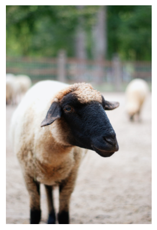

```python
# Load the image
image3 = cv2.imread("image3.jpg")

# Display the loaded image using Matplotlib
plt.imshow(cv2.cvtColor(image3, cv2.COLOR_BGR2RGB))
plt.axis('off')  # Turn off axis labels
plt.show()
```

```python
# Display the image of the magnitude of its Fourier transform
```

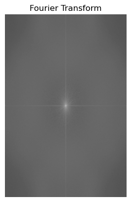

```python
# Convert the image to grayscale
gray3 = cv2.cvtColor(image3, cv2.COLOR_BGR2GRAY)

# Compute the discrete Fourier Transform of the image
fourier3 = cv2.dft(np.float32(gray3), flags=cv2.DFT_COMPLEX_OUTPUT)

# Shift the zero-frequency component to the center of the spectrum
fourier_shift = np.fft.fftshift(fourier3)

# Calculate the magnitude of the Fourier Transform
magnitude = 20 * np.log(cv2.magnitude(fourier_shift[:, :, 0], fourier_shift[:, :, 1]))

# Scale the magnitude for display
magnitude3 = cv2.normalize(magnitude, None, 0, 255, cv2.NORM_MINMAX, cv2.CV_8UC1)

# Display the magnitude of the Fourier Transform using matplotlib
plt.imshow(magnitude3, cmap='gray')
plt.title('Fourier Transform')
plt.axis('off')  # Turn off axis labels
plt.show()
```

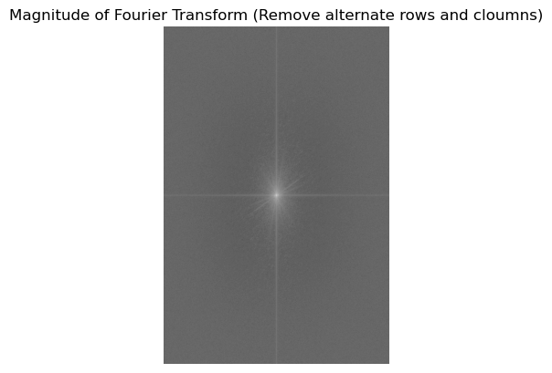

```python
# Remove alternate rows and columns from the grayscale image
gray_subsampled3 = gray3[::2, ::2]

# Compute the discrete Fourier Transform of the subsampled image
fourier3_1 = cv2.dft(np.float32(gray_subsampled3), flags=cv2.DFT_COMPLEX_OUTPUT)

# Shift the zero-frequency component to the center of the spectrum
fourier_shift = np.fft.fftshift(fourier3_1)

# Calculate the magnitude of the Fourier Transform
magnitude = 20 * np.log(cv2.magnitude(fourier_shift[:, :, 0], fourier_shift[:, :, 1]))

# Scale the magnitude for display
magnitude3_1 = cv2.normalize(magnitude, None, 0, 255, cv2.NORM_MINMAX, cv2.CV_8UC1)

# Display the magnitude of the Fourier Transform using matplotlib
plt.imshow(magnitude3_1, cmap='gray')
plt.title('Magnitude of Fourier Transform (Remove alternate rows and cloumns)')
plt.axis('off')  # Turn off axis labels
plt.show()
```

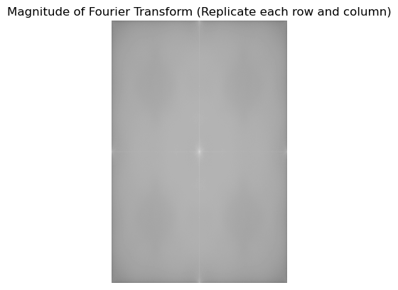

```python
# Replicate each row and column of the grayscale image
gray_expanded3 = gray3.repeat(2, axis=0).repeat(2, axis=1)

# Compute the discrete Fourier Transform of the expanded image
fourier3_2 = cv2.dft(np.float32(gray_expanded3), flags=cv2.DFT_COMPLEX_OUTPUT)

# Shift the zero-frequency component to the center of the spectrum
fourier_shift = np.fft.fftshift(fourier3_2)

# Calculate the magnitude of the Fourier Transform with a small constant added to avoid divide by zero
magnitude = 20 * np.log(cv2.magnitude(fourier_shift[:, :, 0], fourier_shift[:, :, 1]) + 1e-6)

# Scale the magnitude for display
magnitude3_2 = cv2.normalize(magnitude, None, 0, 255, cv2.NORM_MINMAX, cv2.CV_8UC1)

# Display the magnitude of the Fourier Transform using matplotlib
plt.imshow(magnitude3_2, cmap='gray')
plt.title('Magnitude of Fourier Transform (Replicate each row and column)')
plt.axis('off')  # Turn off axis labels
plt.show()
```

```python
# Image 4
# Read in and display the image
```

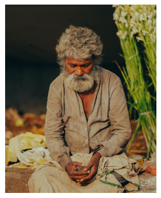

```python
# Load the image
image4 = cv2.imread("image4.jpg")

# Display the loaded image using Matplotlib
plt.imshow(cv2.cvtColor(image4, cv2.COLOR_BGR2RGB))
plt.axis('off')  # Turn off axis labels
plt.show()
```

```python
# Display the image of the magnitude of its Fourier transform
```

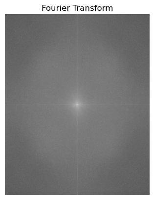

```python
# Convert the image to grayscale
gray4 = cv2.cvtColor(image4, cv2.COLOR_BGR2GRAY)

# Compute the discrete Fourier Transform of the image
fourier4 = cv2.dft(np.float32(gray4), flags=cv2.DFT_COMPLEX_OUTPUT)

# Shift the zero-frequency component to the center of the spectrum
fourier_shift = np.fft.fftshift(fourier4)

# Calculate the magnitude of the Fourier Transform
magnitude = 20 * np.log(cv2.magnitude(fourier_shift[:, :, 0], fourier_shift[:, :, 1]))

# Scale the magnitude for display
magnitude4 = cv2.normalize(magnitude, None, 0, 255, cv2.NORM_MINMAX, cv2.CV_8UC1)

# Display the magnitude of the Fourier Transform using matplotlib
plt.imshow(magnitude4, cmap='gray')
plt.title('Fourier Transform')
plt.axis('off')  # Turn off axis labels
plt.show()
```

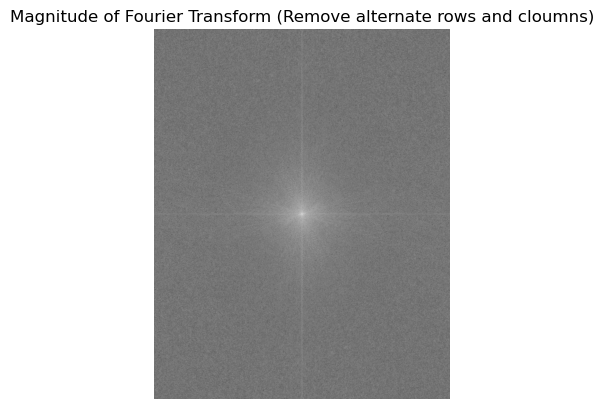

```python
# Remove alternate rows and columns from the grayscale image
gray_subsampled4 = gray4[::2, ::2]

# Compute the discrete Fourier Transform of the subsampled image
fourier4_1 = cv2.dft(np.float32(gray_subsampled4), flags=cv2.DFT_COMPLEX_OUTPUT)

# Shift the zero-frequency component to the center of the spectrum
fourier_shift = np.fft.fftshift(fourier4_1)

# Calculate the magnitude of the Fourier Transform
magnitude = 20 * np.log(cv2.magnitude(fourier_shift[:, :, 0], fourier_shift[:, :, 1]))

# Scale the magnitude for display
magnitude4_1 = cv2.normalize(magnitude, None, 0, 255, cv2.NORM_MINMAX, cv2.CV_8UC1)

# Display the magnitude of the Fourier Transform using matplotlib
plt.imshow(magnitude4_1, cmap='gray')
plt.title('Magnitude of Fourier Transform (Remove alternate rows and cloumns)')
plt.axis('off')  # Turn off axis labels
plt.show()
```

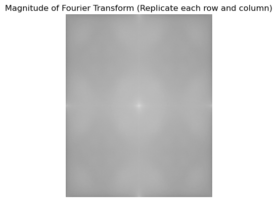

```python
# Replicate each row and column of the grayscale image
gray_expanded4 = gray4.repeat(2, axis=0).repeat(2, axis=1)

# Compute the discrete Fourier Transform of the expanded image
fourier4_2 = cv2.dft(np.float32(gray_expanded4), flags=cv2.DFT_COMPLEX_OUTPUT)

# Shift the zero-frequency component to the center of the spectrum
fourier_shift = np.fft.fftshift(fourier4_2)

# Calculate the magnitude of the Fourier Transform with a small constant added to avoid divide by zero
magnitude = 20 * np.log(cv2.magnitude(fourier_shift[:, :, 0], fourier_shift[:, :, 1]) + 1e-6)

# Scale the magnitude for display
magnitude4_2 = cv2.normalize(magnitude, None, 0, 255, cv2.NORM_MINMAX, cv2.CV_8UC1)

# Display the magnitude of the Fourier Transform using matplotlib
plt.imshow(magnitude4_2, cmap='gray')
plt.title('Magnitude of Fourier Transform (Replicate each row and column)')
plt.axis('off')  # Turn off axis labels
plt.show()
```

```python
# Image 5
# Read in and display the image
```

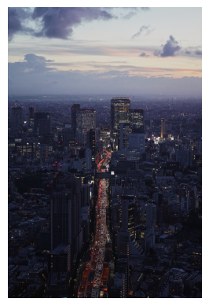

```python
# Load the image
image5 = cv2.imread("image5.jpg")

# Display the loaded image using Matplotlib
plt.imshow(cv2.cvtColor(image5, cv2.COLOR_BGR2RGB))
plt.axis('off')  # Turn off axis labels
plt.show()
```

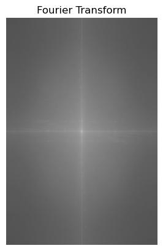

```python
# Convert the image to grayscale
gray5 = cv2.cvtColor(image5, cv2.COLOR_BGR2GRAY)

# Compute the discrete Fourier Transform of the image
fourier5 = cv2.dft(np.float32(gray5), flags=cv2.DFT_COMPLEX_OUTPUT)

# Shift the zero-frequency component to the center of the spectrum
fourier_shift = np.fft.fftshift(fourier5)

# Calculate the magnitude of the Fourier Transform
magnitude = 20 * np.log(cv2.magnitude(fourier_shift[:, :, 0], fourier_shift[:, :, 1]))

# Scale the magnitude for display
magnitude5 = cv2.normalize(magnitude, None, 0, 255, cv2.NORM_MINMAX, cv2.CV_8UC1)

# Display the magnitude of the Fourier Transform using matplotlib
plt.imshow(magnitude5, cmap='gray')
plt.title('Fourier Transform')
plt.axis('off')  # Turn off axis labels
plt.show()
```

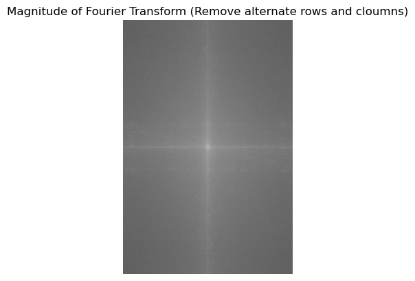

```python
# Remove alternate rows and columns from the grayscale image
gray_subsampled5 = gray5[::2, ::2]

# Compute the discrete Fourier Transform of the subsampled image
fourier5_1 = cv2.dft(np.float32(gray_subsampled5), flags=cv2.DFT_COMPLEX_OUTPUT)

# Shift the zero-frequency component to the center of the spectrum
fourier_shift = np.fft.fftshift(fourier5_1)

# Calculate the magnitude of the Fourier Transform
magnitude = 20 * np.log(cv2.magnitude(fourier_shift[:, :, 0], fourier_shift[:, :, 1]))

# Scale the magnitude for display
magnitude5_1 = cv2.normalize(magnitude, None, 0, 255, cv2.NORM_MINMAX, cv2.CV_8UC1)

# Display the magnitude of the Fourier Transform using matplotlib
plt.imshow(magnitude5_1, cmap='gray')
plt.title('Magnitude of Fourier Transform (Remove alternate rows and cloumns)')
plt.axis('off')  # Turn off axis labels
plt.show()
```

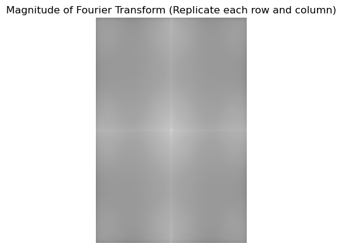

```python
# Replicate each row and column of the grayscale image
gray_expanded5 = gray5.repeat(2, axis=0).repeat(2, axis=1)

# Compute the discrete Fourier Transform of the expanded image
fourier5_2 = cv2.dft(np.float32(gray_expanded5), flags=cv2.DFT_COMPLEX_OUTPUT)

# Shift the zero-frequency component to the center of the spectrum
fourier_shift = np.fft.fftshift(fourier5_2)

# Calculate the magnitude of the Fourier Transform with a small constant added to avoid divide by zero
magnitude = 20 * np.log(cv2.magnitude(fourier_shift[:, :, 0], fourier_shift[:, :, 1]) + 1e-6)

# Scale the magnitude for display
magnitude5_2 = cv2.normalize(magnitude, None, 0, 255, cv2.NORM_MINMAX, cv2.CV_8UC1)

# Display the magnitude of the Fourier Transform using matplotlib
plt.imshow(magnitude5_2, cmap='gray')
plt.title('Magnitude of Fourier Transform (Replicate each row and column)')
plt.axis('off')  # Turn off axis labels
plt.show()
```

### 5. What do you conclude about the effects of the changes to the images? Comment on whether and how the changes depended on the content of the original image

#### The effects of the changes to the images, including subsampling (removing alternate rows and columns) and expansion (replicating each row and column), depend on the content of the original image and the specific operations applied.

#### Subsampling reduces the resolution of the image by removing every other row and column. As a result, the image becomes smaller and loses some fine details.

#### The impact of subsampling depends on the content of the original image. Images with fine textures and high-frequency details will suffer more loss of detail compared to images with smoother, low-frequency content. Subsampling can lead to aliasing artifacts in images with high-frequency components.

#### Expansion increases the resolution of the image by replicating each row and column. This results in a larger image with the same content, making it appear more detailed but also potentially introducing artifacts due to replication.

#### The impact of expansion also depends on the content of the original image. Images with high-frequency components might appear artificially sharpened and exhibit blocky artifacts due to the replication of details. On the other hand, images with smooth transitions might benefit from an increase in apparent detail.

#### The effects of subsampling and expansion on image content and its Fourier Transform depend on the specific characteristics of the original image. The presence of high-frequency or low-frequency components, as well as the nature of details in the image, will influence the visual outcomes of these operations. Therefore, the impact on the content and its Fourier Transform should be considered in a case-by-case manner when performing such operations for analysis or visualization.